# Spatial analysis of census and traffic stop data using R

Andrew Ba Tran

August 6, 2016

We use R at Trend CT not just for data analysis and creating data visualizations, but also for working with spatial analysis and creating geographic graphics.

If you have a data set with latitude and longitude data, [it’s easy](http://trendct.org/2015/06/26/tutorial-how-to-put-dots-on-a-leaflet-map-with-r/) to just throw it on a map with a dot for every instance. But really what does it serve? You see the intensity of the cluster of dots over the area but that’s it. If there’s no context or explanation it’s a flashy visualization and that’s it.

This tutorial will show you how to dig deeper and tell better stories with location data.

We’ll be working with traffic stop data.

We’ll figure out which town and census tract each stop occurred in and then pull in demographic data from the Census to determine what types of neighborhoods police tend to pull people over more often.

You could conduct this analysis using software like ArcGIS or QGIS but we’re going to be doing it all in R.

It is better to stay in a single environment from data importing, to analysis, to exporting visualizations because the produced scripts make it easier for others (including your future self) to replicate and verify your work in the future.

### Difficulty level

Advanced. We’ll be using many packages, including dplyr (for [pipes](http://trendct.org/2015/06/26/tutorial-how-to-put-dots-on-a-leaflet-map-with-r/#chapterTOC2), as well as working with [shape files](http://trendct.org/2015/05/29/tutorial-how-to-merge-data-from-two-different-maps-using-qgis/) and [census data](http://trendct.org/2015/08/14/tutorial-how-to-understand-and-retrieve-census-data-for-beginners/). You should have a basic understanding of these concepts before continuing.

Go through the [beginner tutorial](http://trendct.org/2015/06/12/r-for-beginners-how-to-transition-from-excel-to-r/) to get R and RStudio [installed](http://trendct.org/2015/06/12/r-for-beginners-how-to-transition-from-excel-to-r/#chapterTOC1) before you begin.

Download the dataset, set the working directory, and follow along. You can also skip straight to the full script.

### Importing and preparing the data

```r
# Bring in the data
stops <- read.csv("https://github.com/trendct/walkthroughs/raw/master/spatial-analysis-r-walkthrough/data/hamden_stops.csv", stringsAsFactors=FALSE)

# Check and eliminate the rows that don't have location information
stops <- stops[!is.na(stops$InterventionLocationLatitude),]

# Add a column to identifying a driver as white or a minority
stops$ethnicity <- ifelse(((stops$SubjectRaceCode ==  "W") & (stops$SubjectEthnicityCode =="N")), "White", "Minority")
```

### Importing the shapefiles

```r
# Bring in the shape files for census tracts

require(rgdal)

# dsn is the folder the shape files are in. layer is the name of the file.
towntracts <- readOGR(dsn="shapes", layer="census_tracts")
```

```r
# creating a copy
towntracts_only <- towntracts

# turn the shapefile into a dataframe that can be worked on in R
require(maptools)
require(ggplot2)

towntracts <- fortify(towntracts, region="GEOID10")

# So now we have towntracts and towntracts_only
# What's the difference? towntracts is a dataframe and can be seen easily
library(knitr)
kable(head(towntracts))
```

| long | lat | order | hole | piece | id | group |
| --- | --- | --- | --- | --- | --- | --- |
| -73.66336 | 41.04170 | 1 | FALSE | 1 | 09001010101 | 09001010101.1 |
| -73.66348 | 41.04147 | 2 | FALSE | 1 | 09001010101 | 09001010101.1 |
| -73.66362 | 41.04115 | 3 | FALSE | 1 | 09001010101 | 09001010101.1 |
| -73.66410 | 41.04023 | 4 | FALSE | 1 | 09001010101 | 09001010101.1 |
| -73.66428 | 41.03983 | 5 | FALSE | 1 | 09001010101 | 09001010101.1 |
| -73.66451 | 41.03934 | 6 | FALSE | 1 | 09001010101 | 09001010101.1 |

```r
# It's for analyzing data and performing joins and calculations

# While towntracts_only is a Large SpatialPolygonsDataFrame

# It's for rendering the spatial data in R graphically
```

### Mapping the data

```r
# We only need the columns with the latitude and longitude
coords <- stops[c("InterventionLocationLongitude", "InterventionLocationLatitude")]

# Making sure we are working with rows that don't have any blanks
coords <- coords[complete.cases(coords),]

library(sp)

# Letting R know that these are specifically spatial coordinates
sp <- SpatialPoints(coords)

# Applying projections to the coordinates so they match up with the shapefile we're joining them with
# More projections information http://trac.osgeo.org/proj/wiki/GenParms
proj4string(sp) <- "+proj=longlat +datum=WGS84 +no_defs +ellps=WGS84 +towgs84=0,0,0"
proj4string(sp)
```

```
## [1] "+proj=longlat +datum=WGS84 +no_defs +ellps=WGS84 +towgs84=0,0,0"
```

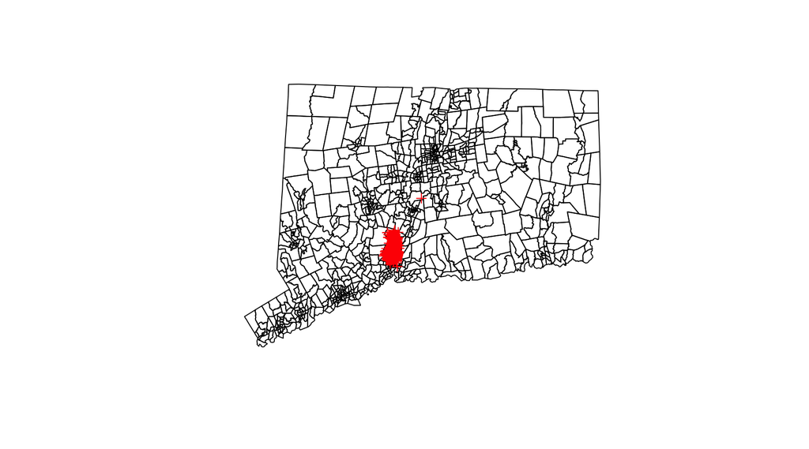

```r
# Rendering the census tracts
plot(towntracts_only)

# Adding the coordinates of the traffic stops
plot(sp, col="red" , add=TRUE)
```

### Points in a polygon

```r
# Calculating points in a polygon

by_tract <- over(sp, towntracts_only)

# What just happened: Every point in the list now has a corresponding census tract
kable(head(by_tract, 5))
```

| STATEFP10 | COUNTYFP10 | TRACTCE10 | GEOID10 | NAME10 | NAMELSAD10 | MTFCC10 | FUNCSTAT10 | ALAND10 | AWATER10 | INTPTLAT10 | INTPTLON10 | GEOID_AFF1 | GEOID_AFF2 |
| --- | --- | --- | --- | --- | --- | --- | --- | --- | --- | --- | --- | --- | --- |
| 09 | 009 | 166001 | 09009166001 | 1660.01 | Census Tract 1660.01 | G5020 | S | 4071781 | 0 | +41.3897855 | -072.9079481 | 14000US09009166001 | 140000US09009166001 |
| 09 | 009 | 165500 | 09009165500 | 1655 | Census Tract 1655 | G5020 | S | 1558578 | 0 | +41.3404053 | -072.9338173 | 14000US09009165500 | 140000US09009165500 |
| 09 | 009 | 165600 | 09009165600 | 1656 | Census Tract 1656 | G5020 | S | 2347326 | 0 | +41.3558996 | -072.9323558 | 14000US09009165600 | 140000US09009165600 |
| 09 | 009 | 141900 | 09009141900 | 1419 | Census Tract 1419 | G5020 | S | 1301209 | 34505 | +41.3223483 | -072.9106575 | 14000US09009141900 | 140000US09009141900 |
| 09 | 009 | 165900 | 09009165900 | 1659 | Census Tract 1659 | G5020 | S | 27028863 | 42903 | +41.4292195 | -072.9366177 | 14000US09009165900 | 140000US09009165900 |

```r
# Use dplyr to gather up and count how many instances of census tracts there are

require(dplyr)

by_tract <- by_tract %>%
  group_by(GEOID10) %>%
  summarise(total=n())

# Get rid of the census tracts with no data
by_tract <- by_tract[!is.na(by_tract$GEOID10),]

kable(head(by_tract,5))
```

| GEOID10 | total |
| --- | --- |
| 09003400200 | 1 |
| 09009141300 | 7 |
| 09009141400 | 3 |
| 09009141500 | 96 |
| 09009141600 | 1 |

```r
# Rename the columns of this datframe so it can be joined to future data
colnames(by_tract) <- c("id", "total")

# Changing the GEOID number to character so it can be joined to future data
by_tract$id <- as.character(by_tract$id)

# Bring in a dataframe that has matches census tract ID numbers to town names
tracts2towns <- read.csv("data/tracts_to_towns.csv", stringsAsFactors=FALSE)

kable(head(tracts2towns, 5))
```

| tract | town |
| --- | --- |
| 9001010101 | Greenwich |
| 9001010102 | Greenwich |
| 9001010201 | Greenwich |
| 9001010202 | Greenwich |
| 9001010300 | Greenwich |

```r
# Changing the column names so it can be joined to the by_tract dataframe
colnames(tracts2towns) <- c("id", "town_name")

# Changing the GEOID number to character so it can be joined to the by_tract dataframe
tracts2towns$id <- as.character(tracts2towns$id)

# Adding a 0 to the front of the GEOID string because it was originally left out when it was imported
tracts2towns$id <- paste0("0", tracts2towns$id)

# Bringing in a library to deal with strings
library(stringr)

# Eliminating leading and trailing white space just in case
tracts2towns$town_name <- str_trim(tracts2towns$town_name)

# Joining the by_tract dataframe to the tracts2towns dataframe

by_tract <- left_join(by_tract, tracts2towns)

kable(head(by_tract,5))
```

| id | total | town_name |
| --- | --- | --- |
| 09003400200 | 1 | Berlin |
| 09009141300 | 7 | New Haven |
| 09009141400 | 3 | New Haven |
| 09009141500 | 96 | New Haven |
| 09009141600 | 1 | New Haven |

```r
# Why did we do this? Because Hamden sometimes made traffic stops outside of its jurisdiction. Now we can tell for sure which towns police overextended themselves.
```

### Making a choropleth

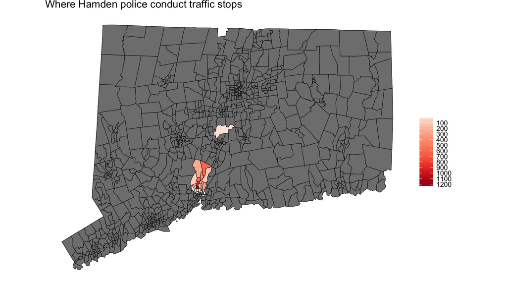

```r
# Now we can finally map it

# Join the by_tract points to polygon dataframe to the original census tracts dataframe
total_map <- left_join(towntracts, by_tract)


require(ggmap)
require(scales)

tm_ct <- ggplot() +
  geom_polygon(data = total_map, aes(x=long, y=lat, group=group, fill=total), color = "black", size=0.2) +
  geom_polygon(data = total_map, aes(x=long, y=lat, group=group, fill=total), color = "black", size=0.2) +
  coord_map() +
  scale_fill_distiller(type="seq", trans="reverse", palette = "Reds", breaks=pretty_breaks(n=10)) +
  theme_nothing(legend=TRUE) +
  labs(title="Where Hamden police conduct traffic stops", fill="")
print(tm_ct)
```

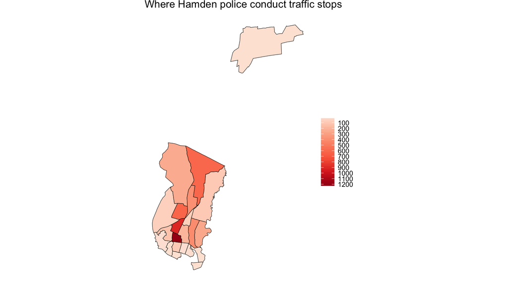

```r
# Excellent. This is a great start but we have a lot of gray tracts.
# Let's try again but without the gray.

# Filter out the tracts with NA in the total column

total_map <- subset(total_map, !is.na(total))

tm_ct <- ggplot() +
  geom_polygon(data = total_map, aes(x=long, y=lat, group=group, fill=total), color = "black", size=0.2) +
  coord_map() +
  scale_fill_distiller(type="seq", trans="reverse", palette = "Reds", breaks=pretty_breaks(n=10)) +
  theme_nothing(legend=TRUE) +
  labs(title="Where Hamden police conduct traffic stops", fill="")
print(tm_ct)
```

```r
# Ok, much better. But we're still unclear which part is Hamden and which are parts of other towns.

townborders <- readOGR(dsn="shapes", layer="ctgeo")
```

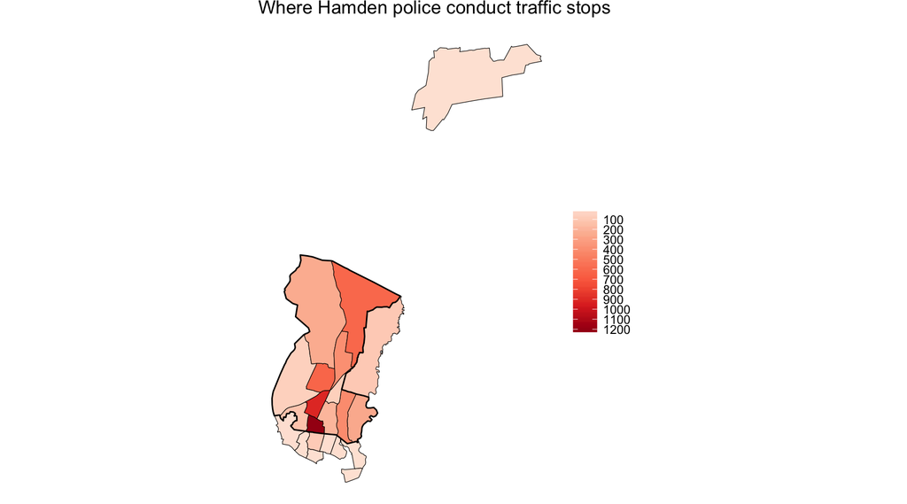

```r
townborders_only <- townborders
townborders<- fortify(townborders, region="NAME10")

# Subset the town borders to just Hamden since that's the department we're looking at
town_borders <- subset(townborders, id=="Hamden")

tm_ct <- ggplot() +
  geom_polygon(data = total_map, aes(x=long, y=lat, group=group, fill=total), color = "black", size=0.2) +
  geom_polygon(data = town_borders, aes(x=long, y=lat, group=group, fill=total), color = "black", fill=NA, size=0.5) +
  coord_map() +
  scale_fill_distiller(type="seq", trans="reverse", palette = "Reds", breaks=pretty_breaks(n=10)) +
  theme_nothing(legend=TRUE) +
  labs(title="Where Hamden police conduct traffic stops", fill="")
print(tm_ct)
```

```r
# That's much clearer
```

```r
# Before we move on, we need to also calculate the number of minority stops in Hamden census tracts

coords <- subset(stops, ethnicity=="Minority")
coords <- coords[c("InterventionLocationLongitude", "InterventionLocationLatitude")]
coords <- coords[complete.cases(coords),]
sp <- SpatialPoints(coords)
proj4string(sp) <- "+proj=longlat +datum=WGS84 +no_defs +ellps=WGS84 +towgs84=0,0,0"
proj4string(sp)
```

```
## [1] "+proj=longlat +datum=WGS84 +no_defs +ellps=WGS84 +towgs84=0,0,0"
```

```r
m_tract <- over(sp, towntracts_only)

m_tract <- m_tract %>%
  group_by(GEOID10) %>%
  summarise(minority=n())

m_tract <- m_tract[!is.na(m_tract$GEOID10),]
colnames(m_tract) <- c("id", "minority")
m_tract$id <- as.character(m_tract$id)

joined_tracts <- left_join(by_tract, m_tract)
kable(head(joined_tracts))
```

| id | total | town_name | minority |
| --- | --- | --- | --- |
| 09003400200 | 1 | Berlin | NA |
| 09009141300 | 7 | New Haven | 6 |
| 09009141400 | 3 | New Haven | 2 |
| 09009141500 | 96 | New Haven | 79 |
| 09009141600 | 1 | New Haven | 1 |
| 09009141800 | 6 | New Haven | 4 |

```r
# Calculating percent of stops that were minorities

joined_tracts$minority_p <- round(joined_tracts$minority/joined_tracts$total*100,2)
kable(head(joined_tracts))
```

| id | total | town_name | minority | minority_p |
| --- | --- | --- | --- | --- |
| 09003400200 | 1 | Berlin | NA | NA |
| 09009141300 | 7 | New Haven | 6 | 85.71 |
| 09009141400 | 3 | New Haven | 2 | 66.67 |
| 09009141500 | 96 | New Haven | 79 | 82.29 |
| 09009141600 | 1 | New Haven | 1 | 100.00 |
| 09009141800 | 6 | New Haven | 4 | 66.67 |

### Importing census data

```r
# We'll be using the censusapi package from Hanna Recht
# https://github.com/hrecht/censusapi
# Some documentation
# http://urbaninstitute.github.io/R-Trainings/accesing-census-apis/presentation/index.html

# If you do not yet have the censusapi package installed, uncomment the lines below and run them.

#install.packages("devtools")
#devtools::install_github("hrecht/censusapi")
library("censusapi")

# Loading my census key from an external script
source("keys.R")

# Replace census_key below with "your_own_key_whatever_it_is"
# Apply for one here http://api.census.gov/data/key_signup.html

race_tracts <- getCensus(name="acs5",
    vintage=2014,
    key=census_key,
    vars=c("NAME", "B02001_001E", "B02001_002E"),
    region="tract:*", regionin="state:09")

# What did we just do?

# I pulled the following population data for all census tracts in state 09, which is Connecticut

# B02001_001E - Total
# B02001_002E - White alone

kable(head(race_tracts))
```

| NAME | state | county | tract | B02001_001E | B02001_002E |
| --- | --- | --- | --- | --- | --- |
| Census Tract 101.01, Fairfield County, Connecticut | 09 | 001 | 010101 | 4392 | 4050 |
| Census Tract 101.02, Fairfield County, Connecticut | 09 | 001 | 010102 | 4134 | 3800 |
| Census Tract 102.01, Fairfield County, Connecticut | 09 | 001 | 010201 | 3387 | 2928 |
| Census Tract 102.02, Fairfield County, Connecticut | 09 | 001 | 010202 | 5066 | 4447 |
| Census Tract 103, Fairfield County, Connecticut | 09 | 001 | 010300 | 4209 | 3846 |
| Census Tract 104, Fairfield County, Connecticut | 09 | 001 | 010400 | 5701 | 4968 |

```r
# ok, let's clean this up
race_tracts$NAME <- NULL

# Creating a new column for the GEOID that can be joined with the dataframe we already have
race_tracts$id <- paste0(race_tracts$state, race_tracts$county, race_tracts$tract)

# Renaming the column names for clarity
colnames(race_tracts) <- c("state_code", "county_code", "tract_code", "total_pop", "white_pop", "id")
```

### Calculating disparity

```r
# Making some calculations

# Determining the minority population by subtracting the white population from the total
race_tracts$minority_pop <- race_tracts$total_pop - race_tracts$white_pop

# Now figuring out the percent makeup of each census tract
race_tracts$white_pop_p <- round(race_tracts$white_pop/race_tracts$total_pop*100,2)
race_tracts$minority_pop_p <- round(race_tracts$minority_pop/race_tracts$total_pop*100,2)

kable(head(race_tracts,5))
```

| state_code | county_code | tract_code | total_pop | white_pop | id | minority_pop | white_pop_p | minority_pop_p |
| --- | --- | --- | --- | --- | --- | --- | --- | --- |
| 09 | 001 | 010101 | 4392 | 4050 | 09001010101 | 342 | 92.21 | 7.79 |
| 09 | 001 | 010102 | 4134 | 3800 | 09001010102 | 334 | 91.92 | 8.08 |
| 09 | 001 | 010201 | 3387 | 2928 | 09001010201 | 459 | 86.45 | 13.55 |
| 09 | 001 | 010202 | 5066 | 4447 | 09001010202 | 619 | 87.78 | 12.22 |
| 09 | 001 | 010300 | 4209 | 3846 | 09001010300 | 363 | 91.38 | 8.62 |

```r
# Joining the two datframes
joined_tracts <- left_join(joined_tracts, race_tracts)

kable(head(joined_tracts,5))
```

| id | total | town_name | minority | minority_p | state_code | county_code | tract_code | total_pop | white_pop | minority_pop | white_pop_p | minority_pop_p |
| --- | --- | --- | --- | --- | --- | --- | --- | --- | --- | --- | --- | --- |
| 09003400200 | 1 | Berlin | NA | NA | 09 | 003 | 400200 | 5893 | 5592 | 301 | 94.89 | 5.11 |
| 09009141300 | 7 | New Haven | 6 | 85.71 | 09 | 009 | 141300 | 5951 | 2984 | 2967 | 50.14 | 49.86 |
| 09009141400 | 3 | New Haven | 2 | 66.67 | 09 | 009 | 141400 | 4968 | 1051 | 3917 | 21.16 | 78.84 |
| 09009141500 | 96 | New Haven | 79 | 82.29 | 09 | 009 | 141500 | 6166 | 353 | 5813 | 5.72 | 94.28 |
| 09009141600 | 1 | New Haven | 1 | 100.00 | 09 | 009 | 141600 | 4884 | 1084 | 3800 | 22.19 | 77.81 |

```r
# Calculating disparity between minority traffic stops and population

joined_tracts$min_disp <- joined_tracts$minority_p - joined_tracts$minority_pop_p

kable(head(joined_tracts[c("tract_code", "min_disp")]))
```

| tract_code | min_disp |
| --- | --- |
| 400200 | NA |
| 141300 | 35.85 |
| 141400 | -12.17 |
| 141500 | -11.99 |
| 141600 | 22.19 |
| 141800 | 11.23 |

### Visualizing geographic disparity

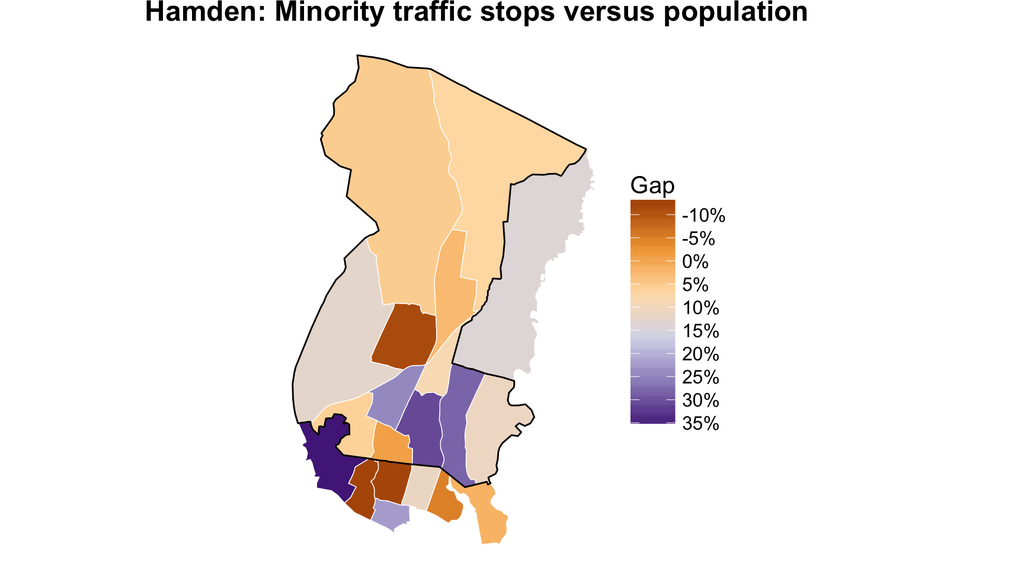

```r
mapping_disparity <- left_join(towntracts, joined_tracts)
mapping_disparity <- subset(mapping_disparity, !is.na(min_disp))

# A library for color scales

pm_ct <- ggplot()
pm_ct <- pm_ct + geom_polygon(data = mapping_disparity, aes(x=long, y=lat, group=group, fill=min_disp/100), color="white", size=.25)
pm_ct <- pm_ct + geom_polygon(data = town_borders, aes(x=long, y=lat, group=group), fill=NA, color = "black", size=0.5)
pm_ct <- pm_ct + coord_map()
pm_ct <- pm_ct + scale_fill_distiller(type="seq", trans="reverse", palette = "PuOr", label=percent, breaks=pretty_breaks(n=10), name="Gap")
pm_ct <- pm_ct + theme_nothing(legend=TRUE)
pm_ct <- pm_ct + labs(x=NULL, y=NULL, title="Hamden: Minority traffic stops versus population")
pm_ct <- pm_ct + theme(text = element_text(size=15))
pm_ct <- pm_ct + theme(plot.title=element_text(face="bold", hjust=.4))
pm_ct <- pm_ct + theme(plot.subtitle=element_text(face="italic", size=9, margin=margin(l=20)))
pm_ct <- pm_ct + theme(plot.caption=element_text(size=12, margin=margin(t=12), color="#7a7d7e", hjust=0))
pm_ct <- pm_ct + theme(legend.key.size = unit(1, "cm"))
print(pm_ct)
```

### Visualizing geographic disparity

#### With annotations

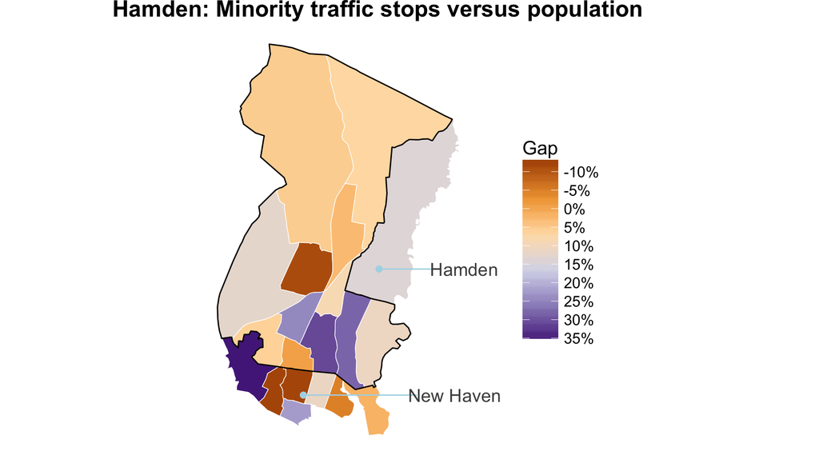

```r
pm_ct <- ggplot()
pm_ct <- pm_ct + geom_polygon(data = mapping_disparity, aes(x=long, y=lat, group=group, fill=min_disp/100), color="white", size=.25)
pm_ct <- pm_ct + geom_polygon(data = town_borders, aes(x=long, y=lat, group=group), fill=NA, color = "black", size=0.5)
pm_ct <- pm_ct + coord_map()
pm_ct <- pm_ct + scale_fill_distiller(type="seq", trans="reverse", palette = "PuOr", label=percent, breaks=pretty_breaks(n=10), name="Gap")
pm_ct <- pm_ct + theme_nothing(legend=TRUE)
pm_ct <- pm_ct + labs(x=NULL, y=NULL, title="Hamden: Minority traffic stops versus population")
pm_ct <- pm_ct + theme(text = element_text(size=15))
pm_ct <- pm_ct + theme(plot.title=element_text(face="bold", hjust=.4))
pm_ct <- pm_ct + theme(plot.subtitle=element_text(face="italic", size=9, margin=margin(l=20)))
pm_ct <- pm_ct + theme(plot.caption=element_text(size=12, margin=margin(t=12), color="#7a7d7e", hjust=0))
pm_ct <- pm_ct + theme(legend.key.size = unit(1, "cm"))

# Annotations

pm_ct <- pm_ct + annotate("segment", x = -72.93, xend = -72.87, y = 41.325, yend = 41.325, colour = "lightblue", size=.5)
pm_ct <- pm_ct + annotate("point", x = -72.93, y = 41.325, colour = "lightblue", size = 2)
pm_ct <- pm_ct + annotate("text", x = -72.85, y = 41.325, label = "New Haven", size=5, colour="gray30")
pm_ct <- pm_ct + annotate("segment", x = -72.89, xend = -72.86, y = 41.375, yend = 41.375, colour = "lightblue", size=.5)
pm_ct <- pm_ct + annotate("point", x = -72.89, y = 41.375, colour = "lightblue", size = 2)
pm_ct <- pm_ct + annotate("text", x = -72.845, y = 41.375, label = "Hamden", size=5, colour="gray30")
pm_ct <- pm_ct + annotate("point", x = -72.83, y = 41.375, colour="white", size=.2)

print(pm_ct)
```